# Measuring Stability

*MoblGamr (MG) is a company that provides a platform that allows end users to play games online on their mobile devices. The company was founded in 2010, and they currently offer over 100 games on their platform, and are considered a leading player in the online gaming market. The company has grown substantially, adding between 10 and 15% new customers every year since its inception.*

*MoblGamr captures key information about each player every time they use the gaming platform. The market research team at MoblGamr would like to use this data to better understand overall trends in the growth of the broader mobile game playing market. The team is concerned that a simple analysis of their own data will bias their understanding of overall market growth. In particular, they know that many customers are increasingly shifting their mobile game playing onto the MoblGamr platform, such that the growth of the use of the MoblGamr platform greatly overstates the growth of the market as a whole.*

*To this end, they have asked you to produce an analysis that will help them identify whether a customer has a “stable” relationship with MoblGamr—customers that likely use MoblGamr for a consistent share of their mobile game playing. Specifically, they have asked for you to produce a number for each customer who used the MoblGamr platform in July 2015 that indicates the “stability” of that customer’s relationship with MoblGamr since July 2014.*

## Stability Measures

### The Relevance of Stability

From the perspective of the firm, user stability speaks to the reliability of the growth figures they see insofar as it permits the firm to distinguish between durable growth and a simple glut. If, for example, there is a great deal of churn in the user base, the growth could be a rather long-lived supply of novel users that ultimately discard the product in a relatively short time period. In this scenario, market potential is lower, because at some point the firm runs through all potential users and some level of decline is imminent. In other words, new users are performing a back-filling function. If users are stable, and continue to use the product, new users are increasing the base instead of replacing those that have left. Consequently, stability is a primary argument in the revenue forecast function.

Future revenue growth is also limited by the size of the entire market. If MG's market share truly is growing faster than the overall market, the rate of growth is untenable in the long-term. If we assume market share growth continues unabated, at some point, the firm just exhausts all potential customers. Thus, revenue growth may decline due to users dropping out of the base or declining available market share. A measure of stability allows one to distinguish between the two. This is important because the marketing strategies differ in these two states of the world. If users are leaving, strategies that target existing users are appropriate. If they are relatively stable, strategies that target new users are appropriate.

### Ideal Characteristics

A good stability measure would tell us the significance of MG within the platform portfolio of each user. This is clearly difficult when we have no information about the rest of the market. In brief, our denominator is absent. Nevertheless, we could learn something if our measure has some or all of the following characteristics:

1. A *continuous* scalar measure facilitates not only the establishment of a easily identified threshold, but also facilitates cross-tabulations if additional attributes become available. That is, retroactive refinement of the stability measure is easier.
2. The indicator should be measureable over a (preferably continuous) range of time periods. This would allow for measurement between dates of significance (e.g. releases of rival games or platforms, changes to hardware, seasonal variation, macroeconomic fluctuation, or changes internal to the firm, just to name a few).
3. The measure should be robust to changes in population-wide game playing time.
4. It should feature, or be mappable to, the probability of exit from the base. Not only does this provide a stability threshold, but it also provides information on which customers are most likely to leave (and therefore should be targeted for intervention).
5. The realized values should be well distributed across the range of potential values. Suppose the measure can take feasible values on the interval [$\alpha$,$\beta$], and nearly all values sit on the interior interval [$x-\epsilon$,$x+\epsilon$]. As $\frac{\epsilon}{\beta-\alpha} \rightarrow 0$, smaller and smaller perturbations in the data lead to material swings in classification (that is, which players are above and below the threshold).
6. The measure would ideally return values that tell us something intrinsic to a given player that lends itself to classification into groups of like players. Although we want a reasonably broad distribution, we want that distribution to be multi-modal. A uniform distribution, for example, would make group boundaries a somewhat arbitrary affair. (Are players at the 75th percentile all that different from those at the 76th?) Some level of clustering is preferred.

### Making the Best of We Have

Since we cannot observe the time each user spends on other platforms, we have no direct way of measuring the share of time spent on the MG platform. We have to estimate portfolio composition entirely from within a very limited data set. The available data provide the following items:

- The user base, defined as anyone who has played an MG game in the covered time period. We do not observe non-MG customers.
- Conditional on inclusion in the observed user base, we can see which games are played.
- Of the games played, we can observe both the frequency and the length of play for each game.

Beyond the unobserved non-MG customers, the other glaring ommission is user attribute data. This could be socioeconomic, geographic, or historical usage data, all of which would be useful in ex ante classification or cross-tabulation. In other words, we have limited handles to explore the data generating process (the latent factor the governs usage) in any robust way. Nevertheless, with some structural assumptions, we have at least few options. *Note that the first two can be skipped if desired. The third imposes the least assumptions/requirements for reasonably high utility.*

- The first option does not actually capture user stability, but it might be useful in a pinch for a firm concerned with measuring market share.
- The second option demonstrates a supervised learning technique, but would be much more appropriate if account closure data were available.
- The third option demonstrates an unsupervised learning technique.

Simple examples of the second two options are executed below, and to do this we will use data generated from a simple agent-based simulation performed in the Notebook called **MG_Data_Sim**.

**Constant Average Game Play Assumption**

If we assume that each additional game purchased by a user requires some amount of time that must come out of the available leisure budget, we may be able to back in to the total leisure budget by measuring the delta in total game play allocated to games already owned by the user. For example, suppose User A has one game (Game 1) on the MG platform, and we assume a presence elsewhere. The leisure budget equation may be characterized in the following way:

$$L = \alpha L + (1-\alpha)L$$

where

- $\alpha$ = share of leisure time allocated to Game 1 (MG)
- $(1-\alpha) = \Sigma_i^n \beta_i$ = share of time allocated to all other games
- $\beta_i$ = the share allocated to each of the other games.

Suppose further that we assume an equal distribution of play time across each game. In other words, $\alpha = \beta_i \quad \forall i$. Yes, this is a very strong assumption, but it helps us identify a system in which we do not know $L$, because then $L = \Sigma_i^n \alpha L$ (where $\alpha$ captures the average time spent playing each game). Thus, we know $\alpha$, but we do not know $n$.

Now, suppose we observe the addition of a new game, Game 2. Further suppose this new entrant induces a *short-run* reduction in playing time for Game 1, $\delta$. If $L$ is constant, our system is suddenly identified because we observe both $\alpha$ and $\delta$.

$$n\alpha = (n+1)(\alpha - \delta) = n(\alpha - \delta) + (\alpha - \delta)$$$$n\alpha + n(\delta - \alpha) = (\alpha - \delta)$$$$n = \frac{(\alpha - \delta)}{\delta}$$

If we look at the central tendency of this behavior (that is, average over all users), we can estimate the size of the market in the short run. Since MG believes its users are growing faster than the market, it provides enough information for a lower bound on market share. The measure clearly leaves a lot to be desired, insofar as it only holds in the short run (that is, $L$ is assumed constant). But, it is better than nothing.

**Estimation of Exit Probability (Supervised Learning)**

The data we possess capture user activity while they are actively engaged with the platform, but the implied idle time can be employed as well. To the extent that we can speak to the relationship between active and idle time, we can make claims about the utilization rate of individual users. Given a data set containing all transactions, one could envision expanding the set to capture all time increments between July 2014 and July 2015. Each customer has two states, playing and not playing. The playing state has attributes indicating the timing and duration of play, as well as the chosen game. With respect to game selection, we can assume that we know something about the overall size of the MG game portfolio. Thus, we have four measures that may be of some use in a supervised learning estimator:

1. *Game starts per unit time (a.k.a utilization rate)* provide information about the consistency of engagement with the platform.
2. *Average game duration* (conditional on game play) provides information on binging behavior. Binging behavior may plausibly speak to the level of enjoyment one gets out of playing the game within any given session.
3. The *coefficient of variation (CoV) in game duration* (conditional on game play) provides information about consistency of experience. Acting in concert with average game duration, the CoV can tell us if the user typically gets bored or engrossed when playing. Since CoV is normalized by average duration, the overlap in informational content with average duration is reduced (the measure is scale invariant).
4. The *total number of games* provides information on how much the user is willing to invest in MG products, and therefore speaks to a somewhat different type of affinity than binging behavior. While it is difficult to parse out whether high frequency purchasers of MG products are biased towards MG or just big spenders on mobile video games, it is likely a safe bet that stable users are more likely to buy several games than users whose relationship with the MG platform is more tenuous.

All of the above are plausible independent measures. In a supervised learning environment, a dependent variable is required as well. In this case, given our threshold-induced binary framework, we want to know the likelihood that a user will exit the user base. Defining exit is not actually a straightforward task because we really do not know if a user that has been idle for awhile will actually stay idle forever. However, given that eternity is a fairly untenable measurement period, it is reasonable to assume that falling below a given utilization rate constitutes exit.

*There is an important caveat here!* One may reasonably ask why we would bother estimating game starts per unit time when in fact we already have it. The purpose of this exercise is to display a technique that would be appropriate if we had data that was actually more definitive from an exit standpoint. We would expect, for example, that MG has data on closed accounts for each user. In that context, we could simply use game starts on the right hand side of the equation.

Utilization rate as a dependent is less than ideal because game starts per unit time is a very intuitive predictor of stability. Since endogeneity is generally a less than helpful addition to an estimation routine, we must be mindful that even a binary indicator of utilization is going to be related to the continuous measure (game starts) by construction. Our mitigation options are limited. First differences are common when dealing with time series to decouple the current and previous observations of the same phenomenon, but both the dependent and independent formulations would largely rely on the same observation window. We do not have sufficient information to develop an instrument. Further, since we will be averaging over several periods to calculate game starts per unit time, fixed effect models would likely wash out the variation from the measure anyway. Finally, there is no intervention present, and our simulated data have a consistent stochastic profile throughout the sample. Consequently, a whole range of structural break related remedies are unavailable. This is a very long way of saying we will be dropping game starts from the right hand side of the specification.

Our model, then, is as follows: `start_rate = f(game_mean, game_cov, game_num)`. We will employ a LASSO regression estimator to model probability of exit, and use the distribution of predicted utilization rates to try and locate a reasonable threshold. Those above the threshold, in this context, are stable users.

**Spatial Clustering (Unsupervised Learning)**

Since there is no known, ex ante label for stable users, an unsupervised learning technique is a reasonable approach. (Unsupervised learning techniques seek to identify patterns in the absence of dependent variable values.) Specifically, we will employ $k$-means clustering. This technique seeks to establish clusters in $p$-dimensional space, where $p$ is the number of independent variables employed. Though it may be less than optimal, we will use only three dimensions, so that we may see the clusters. (More than three dimensions is ... challenging to visualize.)

There is only so much information contained within the data set, so there is little need to further expound upon the measures to be used. Game starts, average duration, and total number of games will define the space. CoV is being dropped. It measures altogether different concepts than game starts and total number of games. Although both average duration and CoV measure in-session concepts, average duration speaks more consistently to the amount of time a user invests in the MG platform. CoV, by contrast, must be coupled with average duration to make sense of whether or not sessions are consistently short, or consistently long.

The $k$-means algorithm seeks to minimize the distance between group members and their centroid, while maximizing the distance between group centroids. A fairly ideal case may be seen below. In the interest of managing expectations, our case will not look quite this good.

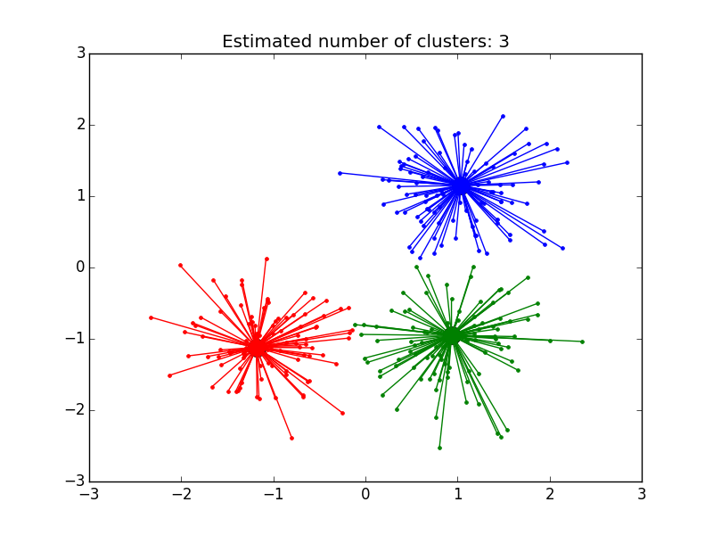

```python
from IPython.display import Image
Image('http://scikit-learn.org/stable/_images/plot_affinity_propagation_001.png')
```

Note that the expository nature of the code below obscures some complexity in real world situations. In the case of $k$-means clustering, the number of clusters ($k$) is an input parameter. We know that three player types exist in the simulated data, so $k$ is being set to three. In the real world, we would need to make judgments about the appropriate number of clusters.

### Simulated Data

To facilitate the provision of actionable code, we will use data that has been simulated. These data were generated by constructing synthetic players, and running through a finite set of time increments. Within each increment, these players were able to make decisions about managing their game stock, game starts (extensive margin), and game duration (intensive margin). The available choices were conditional on their state at that time (playing vs. not playing). As is the case in any simulation context, a number of simplifying assumptions were made:

1. There are three types of players: short-term, sporadic, and heavy users. Heavy users were conceived as the analogue to stable users.
2. The stochastic rules governing decision making are constant throughout the time period.
3. All binary decisions (adding games, dropping games, and starting to play a game) are governed by Bernoulli distributions.
4. The continuous decision (the length of play) is governed by a Beta distribution.
5. Game stock can only be modified during the "non-playing" state.
6. Games are playable, with equal likelihood, at any point in the day.
7. Game starts do not exhibit streaks, they are independently drawn.

To this end, we have sampled 1,000 players for 10,000 time increments each (therefore, we have 10 M observations). The set can be conceived of as an expanded version of the view provided in the question description. The simulation simply accounts for every time increment, not only those that occur while players are playing. The data, while in a different form, are derivable from the information contained in the input sample subset.

```python
#Data Manipulation
import numpy as np
import pandas as pd

#Estimation
import statsmodels.formula.api as smf
import sklearn as sk
from sklearn import linear_model
from sklearn.cluster import KMeans

#Visualization
import seaborn as sb
from mpl_toolkits.mplot3d import Axes3D

%pylab inline
```

## Data Input

```python
data=pd.read_csv("/home/choct155/projects/moblgamr_data.csv",index_col=['id','time'])

data.info()
```

```
<class 'pandas.core.frame.DataFrame'>
MultiIndex: 10000000 entries, (1, 1) to (1000, 10000)
Data columns (total 4 columns):
start     int64
ptime     float64
game      int64
status    int64
dtypes: float64(1), int64(3)
memory usage: 343.4+ MB
```

In general, these data will not cover the entire period considered. They are meant to provide sufficient views of the approaches taken. In a longer-term analysis, a much larger set of simulated data would have been generated, and more would have been done to match operational concepts (like time increments) directly. At 10,000 increments, if we assume each increment is one minute, we are looking at just under a week of potential game time.

```python
10000./(60*24)
```

```
6.944444444444445
```

## Supervised Learning

The first thing we need to do is generate the measures of interest.

```python
#Generate game start indicator
##Generate previous status
data['status_old']=data['status'].shift(1)
##Generate mask
gsi_mask=(data['status']==1) & (data['status_old']==0)
##Generate new game start indicator
data['gstart_I']=np.where(gsi_mask,1,0)
##Drop previous status
data.pop('status_old')

#Define set of player IDs
pids=sorted(set(data.index.get_level_values(level='id')))

#Create container to hold player-specific subsets
player_subs=[]

#For each player...
for p in pids:
    #...capture the subset...
    tmp=data.ix[p].copy(deep=True)
    #...calculate the game play rate...
    tmp['start_rate']=tmp['gstart_I'].mean()
    #...calculate average duration...
    tmp['game_mean']=tmp[tmp['gstart_I']==1]['ptime'].mean()
    #...calculate the standard deviation...
    tmp['game_std']=tmp[tmp['gstart_I']==1]['ptime'].std()
    #...calcuate rolling CoV...
    tmp['game_cov']=tmp['game_std']/tmp['game_mean']
    #...capture the number of games...
    tmp['game_num']=len(set(tmp[tmp['gstart_I']==1]['game']))
    #...reintegrate player id...
    tmp['id']=p
    #...and throw the sub in player_subs
    player_subs.append(tmp)

#Concatenate back together
data=pd.concat(player_subs)

data.head(20)
```

| time | start | ptime | game | status | gstart_I | start_rate | game_mean | game_std | game_cov | game_num | id |
| --- | --- | --- | --- | --- | --- | --- | --- | --- | --- | --- | --- |
| 1 | 1 | 19.738478 | 15 | 0 | 0 | 0.0008 | 24.102154 | 2.530982 | 0.105011 | 3 | 1 |
| 2 | 2 | 26.774451 | 15 | 0 | 0 | 0.0008 | 24.102154 | 2.530982 | 0.105011 | 3 | 1 |
| 3 | 3 | 24.897117 | 15 | 0 | 0 | 0.0008 | 24.102154 | 2.530982 | 0.105011 | 3 | 1 |
| 4 | 4 | 26.656183 | 15 | 0 | 0 | 0.0008 | 24.102154 | 2.530982 | 0.105011 | 3 | 1 |
| 5 | 5 | 21.773310 | 15 | 0 | 0 | 0.0008 | 24.102154 | 2.530982 | 0.105011 | 3 | 1 |
| 6 | 6 | 26.472360 | 15 | 0 | 0 | 0.0008 | 24.102154 | 2.530982 | 0.105011 | 3 | 1 |
| 7 | 7 | 24.460713 | 15 | 0 | 0 | 0.0008 | 24.102154 | 2.530982 | 0.105011 | 3 | 1 |
| 8 | 8 | 25.477340 | 15 | 0 | 0 | 0.0008 | 24.102154 | 2.530982 | 0.105011 | 3 | 1 |
| 9 | 9 | 23.712825 | 15 | 0 | 0 | 0.0008 | 24.102154 | 2.530982 | 0.105011 | 3 | 1 |
| 10 | 10 | 18.689382 | 15 | 0 | 0 | 0.0008 | 24.102154 | 2.530982 | 0.105011 | 3 | 1 |
| 11 | 11 | 22.567707 | 15 | 0 | 0 | 0.0008 | 24.102154 | 2.530982 | 0.105011 | 3 | 1 |
| 12 | 12 | 23.203337 | 15 | 0 | 0 | 0.0008 | 24.102154 | 2.530982 | 0.105011 | 3 | 1 |
| 13 | 13 | 27.902103 | 15 | 0 | 0 | 0.0008 | 24.102154 | 2.530982 | 0.105011 | 3 | 1 |
| 14 | 14 | 17.435904 | 15 | 0 | 0 | 0.0008 | 24.102154 | 2.530982 | 0.105011 | 3 | 1 |
| 15 | 15 | 20.817604 | 15 | 0 | 0 | 0.0008 | 24.102154 | 2.530982 | 0.105011 | 3 | 1 |
| 16 | 16 | 22.598138 | 15 | 0 | 0 | 0.0008 | 24.102154 | 2.530982 | 0.105011 | 3 | 1 |
| 17 | 17 | 26.166711 | 15 | 0 | 0 | 0.0008 | 24.102154 | 2.530982 | 0.105011 | 3 | 1 |
| 18 | 18 | 24.992463 | 15 | 0 | 0 | 0.0008 | 24.102154 | 2.530982 | 0.105011 | 3 | 1 |
| 19 | 19 | 26.299356 | 15 | 0 | 0 | 0.0008 | 24.102154 | 2.530982 | 0.105011 | 3 | 1 |
| 20 | 20 | 19.603286 | 15 | 0 | 0 | 0.0008 | 24.102154 | 2.530982 | 0.105011 | 3 | 1 |

With the summary measures calculated, we can retain only high-level information for each player. Missing mean values indicate no games played. Missing CoV values indicate less than two games played.

```python
data_summ=data.groupby(['id']).first()[['start_rate','game_mean','game_cov','game_num']].fillna(0)

data_summ
```

| id | start_rate | game_mean | game_cov | game_num |
| --- | --- | --- | --- | --- |
| 1 | 0.0008 | 24.102154 | 0.105011 | 3 |
| 2 | 0.0001 | 5.586864 | 0.000000 | 1 |
| 3 | 0.0001 | 2.069678 | 0.000000 | 1 |
| 4 | 0.0006 | 22.443936 | 0.171408 | 3 |
| 5 | 0.0003 | 12.033302 | 0.171192 | 2 |
| 6 | 0.0000 | 0.000000 | 0.000000 | 0 |
| 7 | 0.0007 | 5.935991 | 0.599619 | 1 |
| 8 | 0.0002 | 9.532280 | 0.539229 | 1 |
| 9 | 0.0003 | 15.799140 | 0.169730 | 2 |
| 10 | 0.0000 | 0.000000 | 0.000000 | 0 |
| 11 | 0.0002 | 4.567875 | 0.640933 | 1 |
| 12 | 0.0006 | 24.918552 | 0.135487 | 3 |
| 13 | 0.0002 | 15.146513 | 0.145804 | 2 |
| 14 | 0.0009 | 22.356218 | 0.078593 | 3 |
| 15 | 0.0001 | 6.149108 | 0.000000 | 1 |
| 16 | 0.0001 | 5.698711 | 0.000000 | 1 |
| 17 | 0.0002 | 5.767658 | 0.315417 | 2 |
| 18 | 0.0002 | 18.036277 | 0.056300 | 1 |
| 19 | 0.0003 | 5.652081 | 0.305958 | 1 |
| 20 | 0.0000 | 0.000000 | 0.000000 | 0 |
| 21 | 0.0003 | 26.430965 | 0.106149 | 3 |
| 22 | 0.0002 | 6.728262 | 0.605054 | 2 |
| 23 | 0.0010 | 23.439328 | 0.132378 | 4 |
| 24 | 0.0009 | 23.878536 | 0.137337 | 5 |
| 25 | 0.0010 | 23.263665 | 0.123740 | 3 |
| 26 | 0.0004 | 12.818573 | 0.277965 | 2 |
| 27 | 0.0002 | 9.563819 | 0.010590 | 1 |
| 28 | 0.0002 | 17.498463 | 0.016354 | 2 |
| 29 | 0.0003 | 17.130989 | 0.307261 | 1 |
| 30 | 0.0008 | 23.319120 | 0.151681 | 3 |
| ... | ... | ... | ... | ... |
| 971 | 0.0007 | 22.574602 | 0.177870 | 3 |
| 972 | 0.0003 | 6.344729 | 0.532283 | 2 |
| 973 | 0.0011 | 21.112499 | 0.097785 | 6 |
| 974 | 0.0000 | 0.000000 | 0.000000 | 0 |
| 975 | 0.0009 | 23.679486 | 0.094150 | 3 |
| 976 | 0.0003 | 4.019519 | 0.495988 | 2 |
| 977 | 0.0000 | 0.000000 | 0.000000 | 0 |
| 978 | 0.0001 | 17.659089 | 0.000000 | 1 |
| 979 | 0.0008 | 23.297120 | 0.186633 | 5 |
| 980 | 0.0000 | 0.000000 | 0.000000 | 0 |
| 981 | 0.0003 | 15.083778 | 0.227726 | 2 |
| 982 | 0.0001 | 14.674957 | 0.000000 | 1 |
| 983 | 0.0005 | 22.806098 | 0.182321 | 2 |
| 984 | 0.0007 | 22.319721 | 0.157397 | 4 |
| 985 | 0.0002 | 4.240210 | 0.053641 | 2 |
| 986 | 0.0000 | 0.000000 | 0.000000 | 0 |
| 987 | 0.0002 | 20.564856 | 0.275956 | 1 |
| 988 | 0.0001 | 4.410684 | 0.000000 | 1 |
| 989 | 0.0001 | 7.474990 | 0.000000 | 1 |
| 990 | 0.0006 | 23.294052 | 0.140007 | 4 |
| 991 | 0.0001 | 15.696323 | 0.000000 | 1 |
| 992 | 0.0001 | 18.712654 | 0.000000 | 1 |
| 993 | 0.0002 | 6.151119 | 0.061444 | 2 |
| 994 | 0.0001 | 19.717617 | 0.000000 | 1 |
| 995 | 0.0003 | 7.619221 | 0.608899 | 1 |
| 996 | 0.0001 | 6.061176 | 0.000000 | 1 |
| 997 | 0.0006 | 23.253866 | 0.124372 | 5 |
| 998 | 0.0002 | 20.340131 | 0.162879 | 2 |
| 999 | 0.0008 | 23.731192 | 0.123832 | 5 |
| 1000 | 0.0003 | 10.471430 | 0.198463 | 2 |

1000 rows × 4 columns

What do these data look like?

|  | start_rate | game_mean | game_cov | game_num |
| --- | --- | --- | --- | --- |
| count | 1000.000000 | 1000.000000 | 1000.000000 | 1000.000000 |
| mean | 0.000372 | 12.882133 | 0.135483 | 1.868000 |
| std | 0.000383 | 9.177969 | 0.172947 | 1.627644 |
| min | 0.000000 | 0.000000 | 0.000000 | 0.000000 |
| 25% | 0.000100 | 4.487643 | 0.000000 | 1.000000 |
| 50% | 0.000200 | 13.881305 | 0.104087 | 1.000000 |
| 75% | 0.000600 | 22.434578 | 0.182970 | 3.000000 |
| max | 0.001900 | 26.605559 | 0.955758 | 9.000000 |

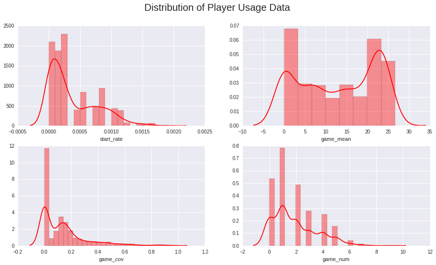

```python
#Generate plot object
fig,ax=plt.subplots(2,2,figsize=(15,8))

#For each variable...
for i,var in enumerate(data_summ.columns):
    #...plot the distribution
    sb.distplot(data_summ[var],ax=ax[i//2,i%2],color='r')

#Add super title
plt.suptitle('Distribution of Player Usage Data',fontsize=20)

data_summ.describe()
```

The prevalence of bimodal data is encouraging from the standpoint of splitting users into groups. We can quickly estimate our model to understand the impacts of "in session" game experience (`game_mean` and `game_cov`) and MG investment (`game_num`) on user attachment to the MG platform (`start_rate`).

```python
#Capture design and response arrays
X_vars=['game_mean','game_cov','game_num']
X=data_summ[X_vars].values
y=data_summ['start_rate'].values

#Initialize estimator
lasso=linear_model.LassoCV(normalize=True,max_iter=5000)

#Fit data
lasso_fit=lasso.fit(X,y)

#Associate coefficient estimates with variable names
lasso_vars=pd.Series(lasso.coef_,index=X_vars)

#Identify non-zero subset
lassoCV_vars=lasso_vars[lasso_vars>0]

print "LASSO Estimator Score:",lasso.score(X,y)

lasso
```

```
LASSO Estimator Score: 0.755968348746
```

```
LassoCV(alphas=None, copy_X=True, cv=None, eps=0.001, fit_intercept=True,
    max_iter=5000, n_alphas=100, n_jobs=1, normalize=True, positive=False,
    precompute='auto', random_state=None, selection='cyclic', tol=0.0001,
    verbose=False)
```

The score indicates that our independent variables (`game_mean`,`game_cov`,`game_num`) explain about 75% of the variation in our dependent variable (`start_rate`). How do the observed utilization rates correspond to the predicted rates?

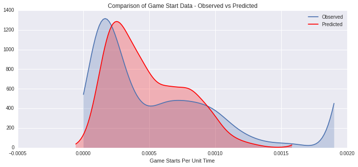

```python
#Generate plot object
fig,ax=plt.subplots(figsize=(12,5))

#Plot data
sb.kdeplot(y,shade=True,label='Observed',cut=0)
sb.kdeplot(lasso.predict(X),color='r',shade=True,label='Predicted',cut=0)

#Set labels
ax.set_xlabel('Game Starts Per Unit Time')
ax.set_title('Comparison of Game Start Data - Observed vs Predicted');
```

The predicted data actually approach preserving the multi-modal nature of the observed data. Furthermore, both vectors experience a categorical change around `start_rate`=0.0005, though the change is not quite as pronounced as we would like. Given limited data, however, this value may have some utility as a threshold.

In the event that account closure data were available, it would be preferable to use a classifier (regression with a binary dependent). A probit model could easily serve this purpose, but it would be wise to engage in a classifier competition. Since prediction is the objective, a variety of approaches could be used that may yield less tractable information regarding the specific contributions of individual predictors. One could employ probit, logit, support vector, random forest, or $k$-nearest neighbor estimators, just to name a few. The estimator with the highest predictive accuracy would be chosen.

## Unsupervised Learning

The first thing we want to do is exploit our knowledge of the known labels. We know which types were used to simulate the data. How do they differ across our metrics? Specifically, how do the average values differ?

```python
#Read in known labels
known_labels=pd.read_csv("/home/choct155/projects/moblgamr_ptypes.csv",index_col=['id'])

#Join labels to data
data_summ['ptype']=known_labels.ix[data_summ.index]

#Capture averages by type
ptype_avg=data_summ.groupby('ptype').mean()[['start_rate','game_mean','game_num']]

ptype_avg
```

| ptype | start_rate | game_mean | game_num |
| --- | --- | --- | --- |
| 1 | 0.000137 | 4.334804 | 0.838617 |
| 2 | 0.000147 | 11.460922 | 1.092063 |
| 3 | 0.000822 | 22.981554 | 3.647929 |

As can be seen, along our three vectors of interest, there are differences that we can exploit in an estimation routine. `ptype_avg` essentially captures the centroids of each player type in 3-dimensional space.

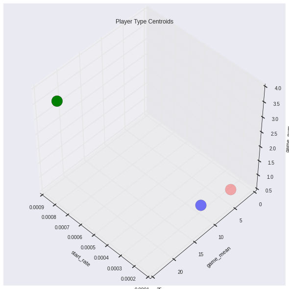

```python
#Map colors
ptype_avg['color']=['r','b','g']

#Generate figure
fig=plt.figure(figsize=(8,8))

#Generate axes
ax=Axes3D(fig,elev=48,azim=134)

#Plot centroids
ax.scatter(ptype_avg['start_rate'],ptype_avg['game_mean'],ptype_avg['game_num'],s=500,c=ptype_avg['color'])

#Fix labels
ax.set_xlabel('start_rate')
ax.set_ylabel('game_mean')
ax.set_zlabel('game_num')
ax.set_title('Player Type Centroids');
```

As can be seen, the heavy users (green) are demonstrably different than sporadic (blue) or short-term (red) users. We will employ $k$-means clustering to group the unsupervised data, as if we did not know which player type generate each observation. If our groups are cleanly separated, we have determined a method of identifying stable (a.k.a. heavy) users.

Now we can fit the model.

```python
#Define vectors to use for estimation
unsup_var=['start_rate','game_mean','game_num']

#Fit model
km=KMeans(n_clusters=3).fit(data_summ[unsup_var].values)

#Assign labels
data_summ['klabs']=km.labels_

#Assign colors based upon kmeans labels
color_map={0:'g',
           1:'b',
           2:'r'}
data_summ['k_col']=data_summ['klabs'].map(color_map)

data_summ.head(20)
```

| id | start_rate | game_mean | game_cov | game_num | ptype | klabs | k_col |
| --- | --- | --- | --- | --- | --- | --- | --- |
| 1 | 0.0008 | 24.102154 | 0.105011 | 3 | 3 | 1 | b |
| 2 | 0.0001 | 5.586864 | 0.000000 | 1 | 1 | 0 | g |
| 3 | 0.0001 | 2.069678 | 0.000000 | 1 | 1 | 0 | g |
| 4 | 0.0006 | 22.443936 | 0.171408 | 3 | 3 | 1 | b |
| 5 | 0.0003 | 12.033302 | 0.171192 | 2 | 2 | 2 | r |
| 6 | 0.0000 | 0.000000 | 0.000000 | 0 | 2 | 0 | g |
| 7 | 0.0007 | 5.935991 | 0.599619 | 1 | 1 | 0 | g |
| 8 | 0.0002 | 9.532280 | 0.539229 | 1 | 1 | 2 | r |
| 9 | 0.0003 | 15.799140 | 0.169730 | 2 | 2 | 2 | r |
| 10 | 0.0000 | 0.000000 | 0.000000 | 0 | 2 | 0 | g |
| 11 | 0.0002 | 4.567875 | 0.640933 | 1 | 1 | 0 | g |
| 12 | 0.0006 | 24.918552 | 0.135487 | 3 | 3 | 1 | b |
| 13 | 0.0002 | 15.146513 | 0.145804 | 2 | 2 | 2 | r |
| 14 | 0.0009 | 22.356218 | 0.078593 | 3 | 3 | 1 | b |
| 15 | 0.0001 | 6.149108 | 0.000000 | 1 | 1 | 0 | g |
| 16 | 0.0001 | 5.698711 | 0.000000 | 1 | 2 | 0 | g |
| 17 | 0.0002 | 5.767658 | 0.315417 | 2 | 1 | 0 | g |
| 18 | 0.0002 | 18.036277 | 0.056300 | 1 | 2 | 1 | b |
| 19 | 0.0003 | 5.652081 | 0.305958 | 1 | 1 | 0 | g |
| 20 | 0.0000 | 0.000000 | 0.000000 | 0 | 1 | 0 | g |

A complicating factor here is that the labels returned from the $k$-Means algorithm are random, and do not necessarily align with the `ptype` labels. Consequently, to get the color of the centroids to match the color of the user-level data, we need to adjust the colors of the centroids from `ptype_avg`.

How well do our predicted labels match with the known player types?

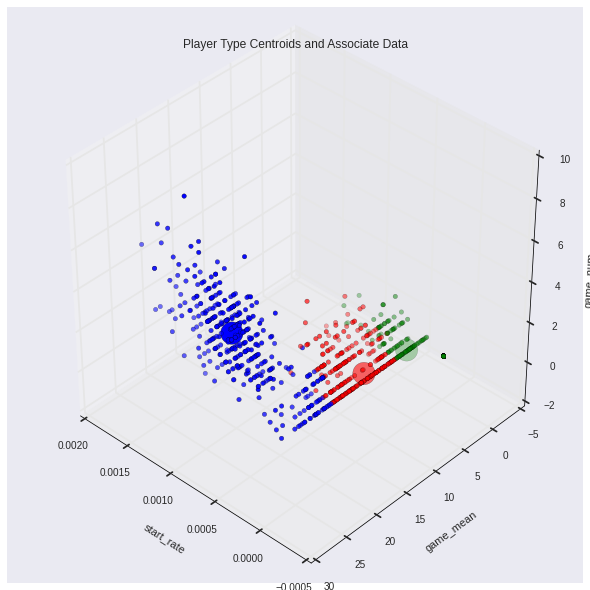

```python
#Map colors for centroids
ptype_avg['color']=['g','r','b']

#Generate figure
fig=plt.figure(figsize=(8,8))

#Generate axes
ax=Axes3D(fig,elev=38,azim=133)

#Plot centroids
ax.scatter(ptype_avg['start_rate'],ptype_avg['game_mean'],ptype_avg['game_num'],s=500,c=ptype_avg['color'])

#Plot user level data
ax.scatter(data_summ['start_rate'],data_summ['game_mean'],data_summ['game_num'],c=data_summ['k_col'])

#Fix labels
ax.set_xlabel('start_rate')
ax.set_ylabel('game_mean')
ax.set_zlabel('game_num')
ax.set_title('Player Type Centroids and Associate Data');
```

As can be seen, $k$-means clustering actually does a fairly good job separating groups from one another. This is indicated by the relatively small amount of overlap.

The lack of restrictive assumptions and the ability to operate within only the existing data make this the best approach by far. MG could employ $k$-means clustering, and simply define stable users as those in the group characterized by heavy usage along a vector of attributes.